# Aula 3

Introdução ao ggplot

Lucas Fernandes de Magalhães

# Visualização de dados

## Por que construir gráficos?

Saia desta sala. Vire à direita e caminhe 3 metros até o final do corredor, onde você estará em frente a uma grande sala de conferências. Vire à esquerda e caminhe mais 3 metros até chegar ao final do corredor. À sua esquerda estará um alarme de incêndio, perto do elevador. À sua direita, no final do corredor, há uma escadaria. Não vá ao elevador. Vire à direita e caminhe mais 4 metros até o final do corredor, vire à esquerda e desça pelas escadas. Desça dois lances de escadas e saia do prédio na porta na parte inferior das escadas.

Fonte: Adaptado de Berinato (2016)

## Por que construir gráficos?

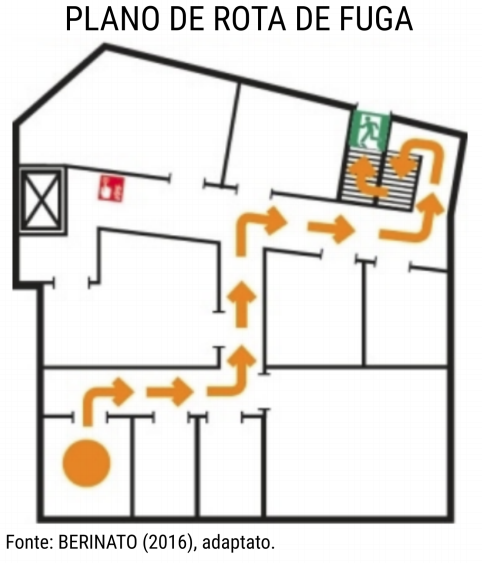

## Por que construir gráficos?

[video not shown]

# Ggplot - Grammar of graphics

## Construção de gráficos em camadas

O ggplot é um pacote criado pelo **Hadley Wickham** com o objetivo de operacionalizar a teoria do livro “The Grammar of Graphics” de Leland Wilkinson.

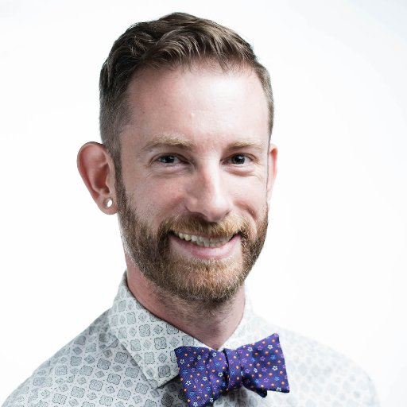

[figure not shown]

## Por que o nome gramática de gráficos?

A ideia básica do ggplot é a de que um gráfico é construído a partir de camadas de elementos, assim como uma frase:

**O JAIR FEZ UM PÉSSIMO DISCURSO**

Se os adjetivos, verbos, ou substantivos fossem alterados, o sentido da frase seria totalmente alterado.

## A Gramática dos Gráficos

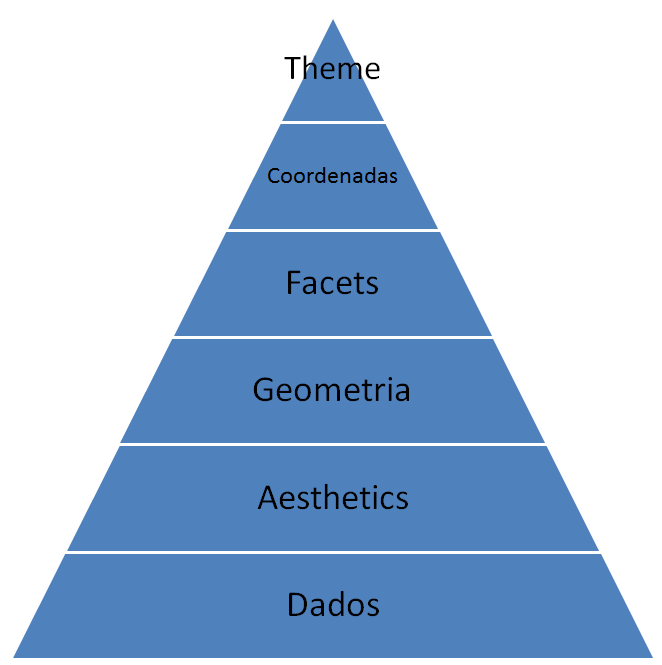

# 1ª Camada: Dados

## Qual é a base a ser utilizada?

O primeira camada é a base de dados utilizada para plotar os gráficos. Obviamente, isso ainda não é suficiente para criar um gráfico

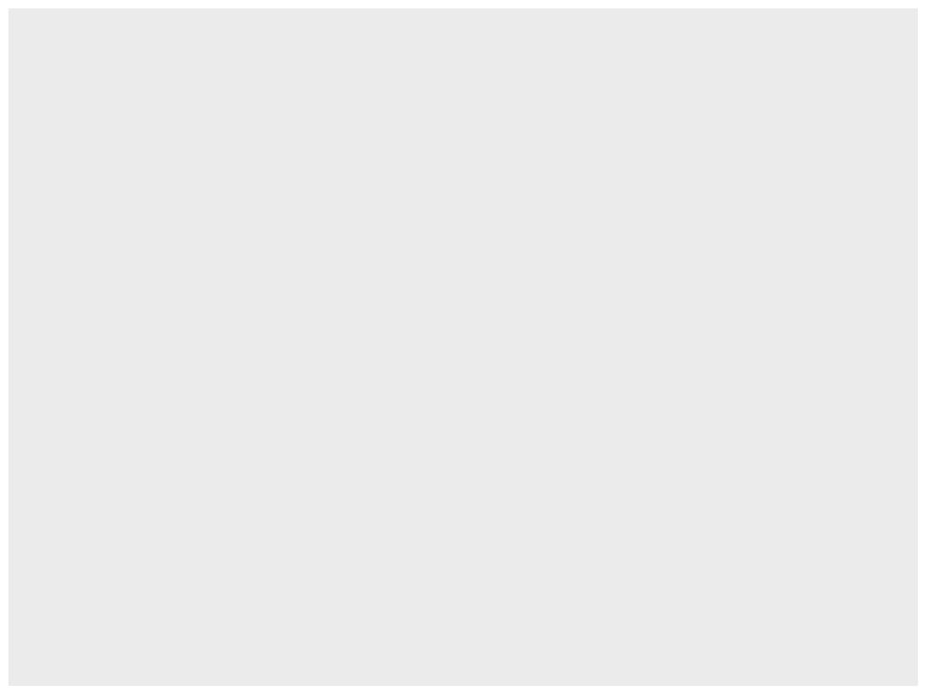

```r
#Carregar os pacotes
#library(tidyverse)
#library(rio)

jn <- import("T:\\COVAD\\Curso R\\Aula 3\\jn.xlsx")
ggplot(data=jn)
```

# 2ª Camada: Aesthetics

## Aesthetics

A segunda camada (Estética) basicamente consiste em dizer para o R o que vai no eixo X e o que vai no eixo Y

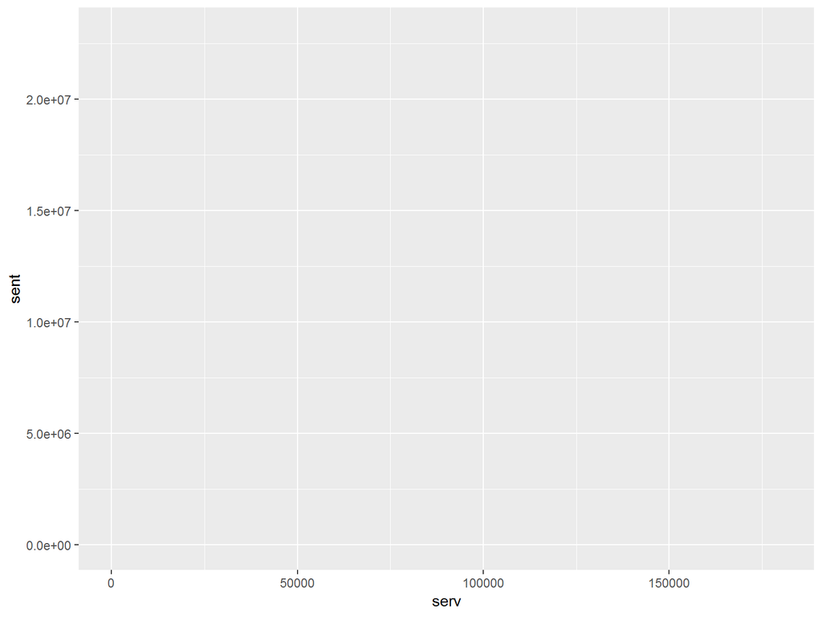

```r
ggplot(data=jn, mapping=aes(x=serv, y=sent))
```

## Aesthetics

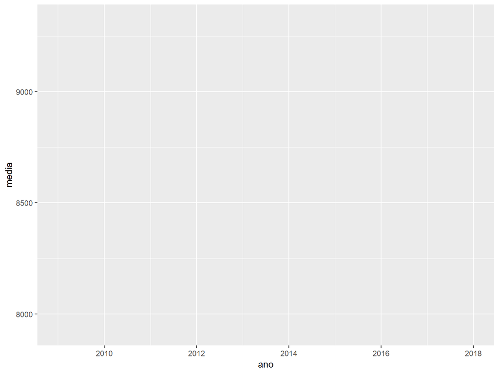

```r
jn1 <- group_by(jn, ano)
jn1 <- summarise(jn1, media=mean(ftt))

ggplot(data=jn1, mapping=aes(x=ano, y=media))
```

# 3º Camada: Geometria

## Geometria

A 3º camada (Geometria) é a responsável pelos elementos visuais do gráfico

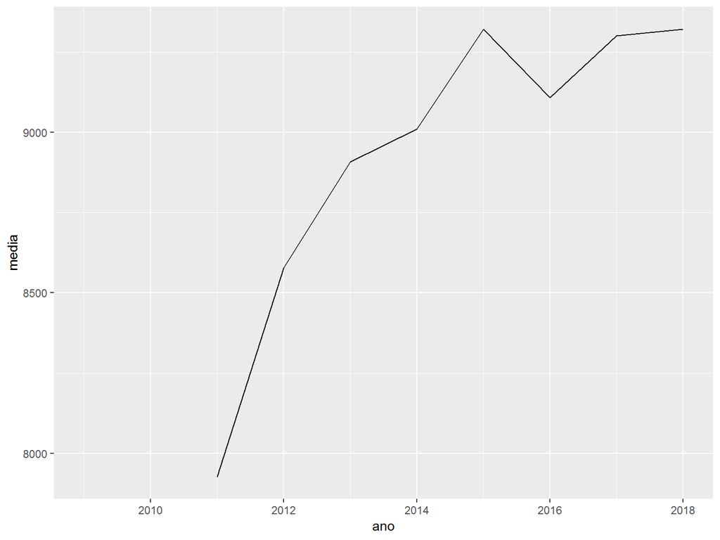

```r
#Usando a geometria de linha

ggplot(data=jn1, mapping=aes(x=ano, y=media))+
  geom_line()
```

## Geometria

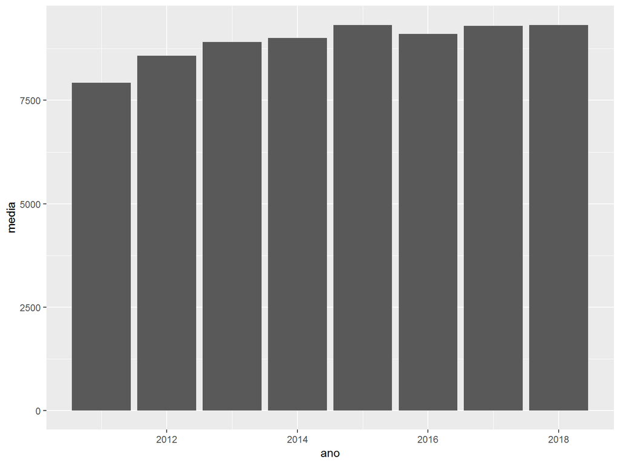

```r
#Usando a geometria de colunas
ggplot(data=jn1, mapping=aes(x=ano, y=media))+
  geom_col()
```

## Geometria

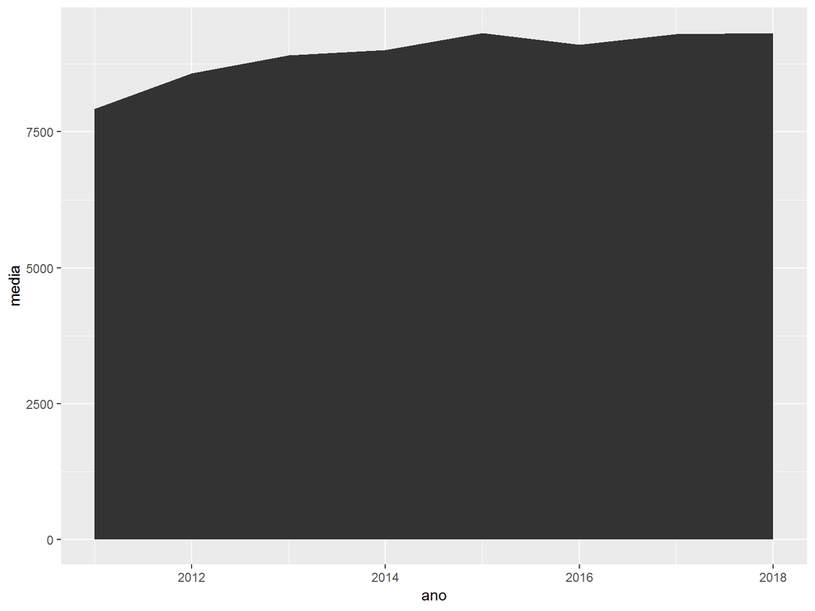

```r
#Usando a geometria de área
ggplot(data=jn1, mapping=aes(x=ano, y=media))+
  geom_area()
```

## Geometria

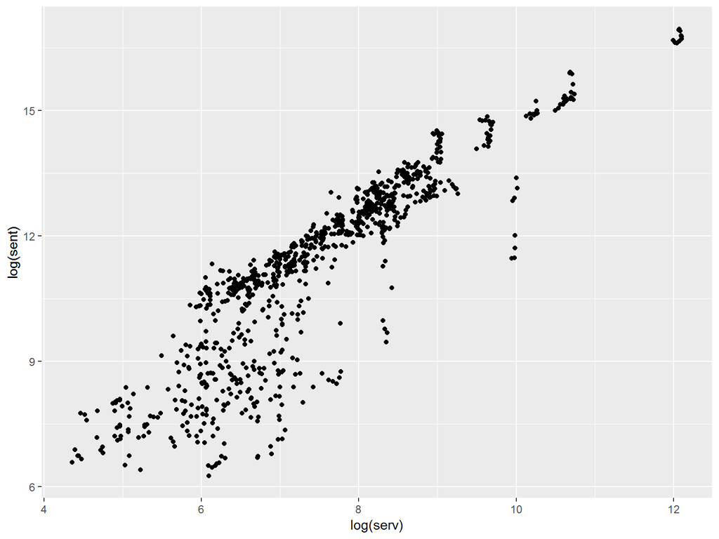

```r
#Usando a geometria de pontos
ggplot(data=jn, mapping=aes(x=log(serv), y=log(sent)))+
  geom_point()
```

# Combinando geometria com aesthetics

## Aumentando as dimensões

Geralmente, precisamos plotar gráficos com mais de 2 duas dimensões. Existem vários argumentos para realizar essa tarefa, como color, group, size, shape, etc. **Obs: Alguns argumentos somente funcionam para alguns tipos de geometrias**

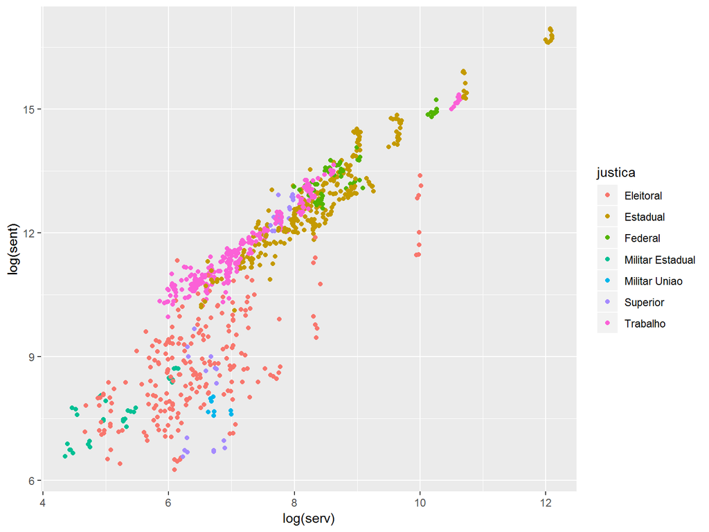

```r
ggplot(data=jn, mapping=aes(x=log(serv), y=log(sent), color=justica))+
  geom_point()
```

## Aumentando as dimensões

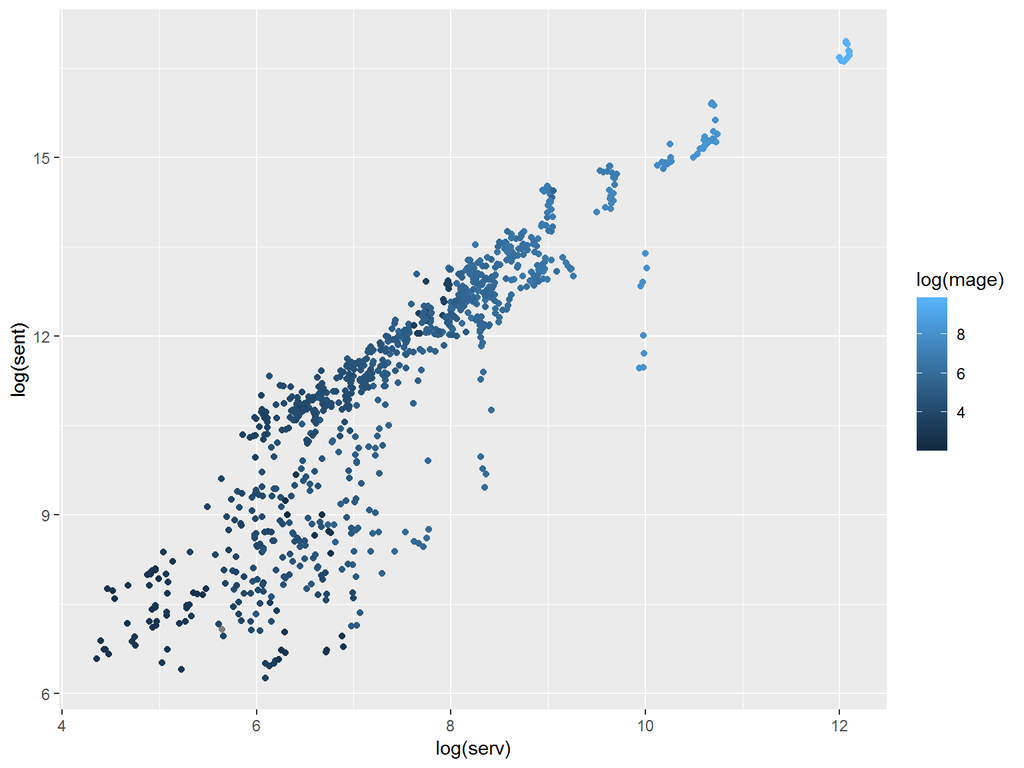

```r
ggplot(data=jn, mapping=aes(x=log(serv), y=log(sent), color=log(mage)))+
  geom_point()
```

## Aumentando as dimensões

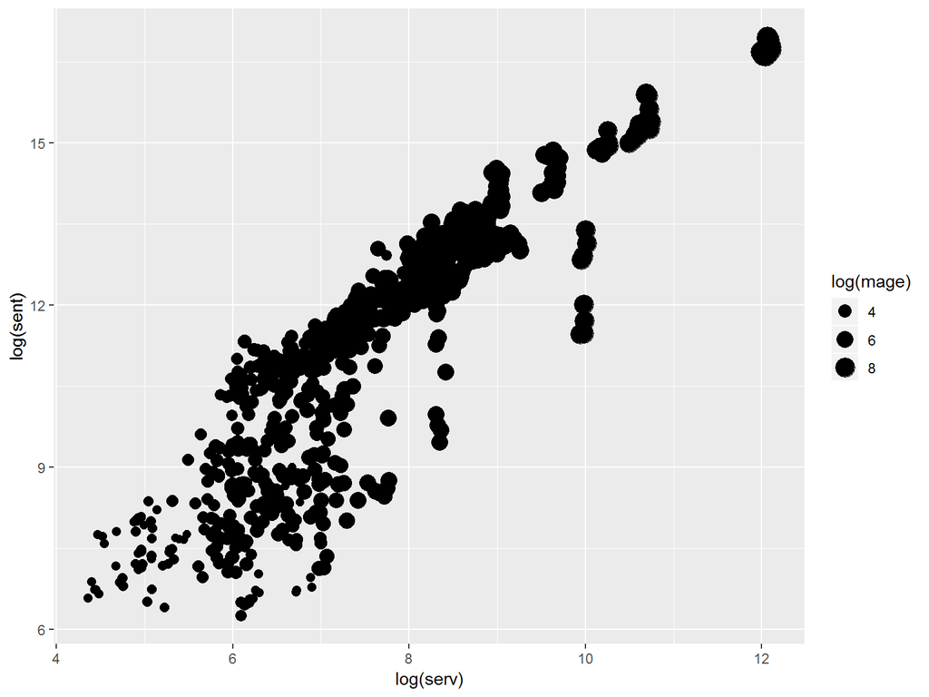

```r
ggplot(data=jn, mapping=aes(x=log(serv), y=log(sent), size=log(mage)))+
  geom_point()
```

## Aumentando as dimensões

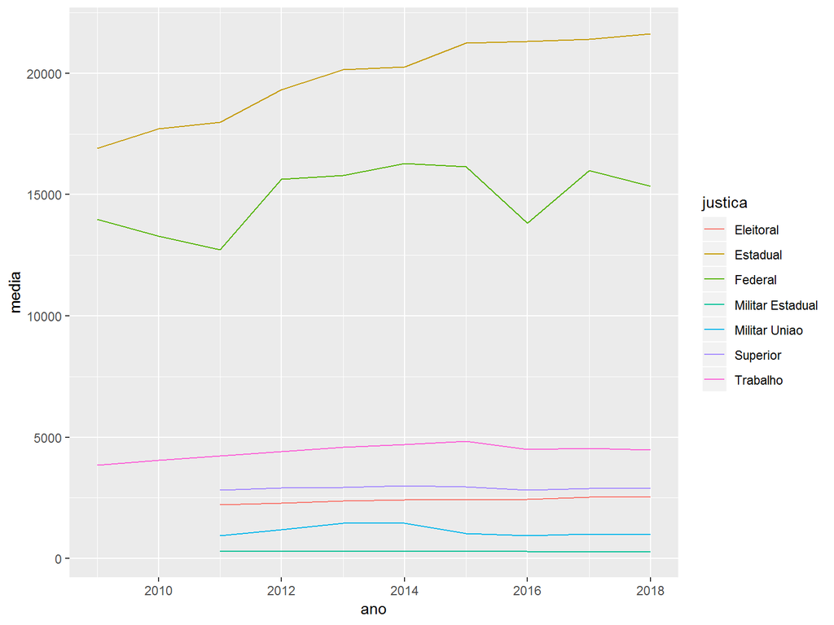

```r
jn1 <- group_by(jn, ano, justica)
jn1 <- summarise(jn1, media=mean(ftt))

ggplot(data=jn1, mapping=aes(x=ano, y=media, color=justica))+
  geom_line()
```

## Aumentando as dimensões

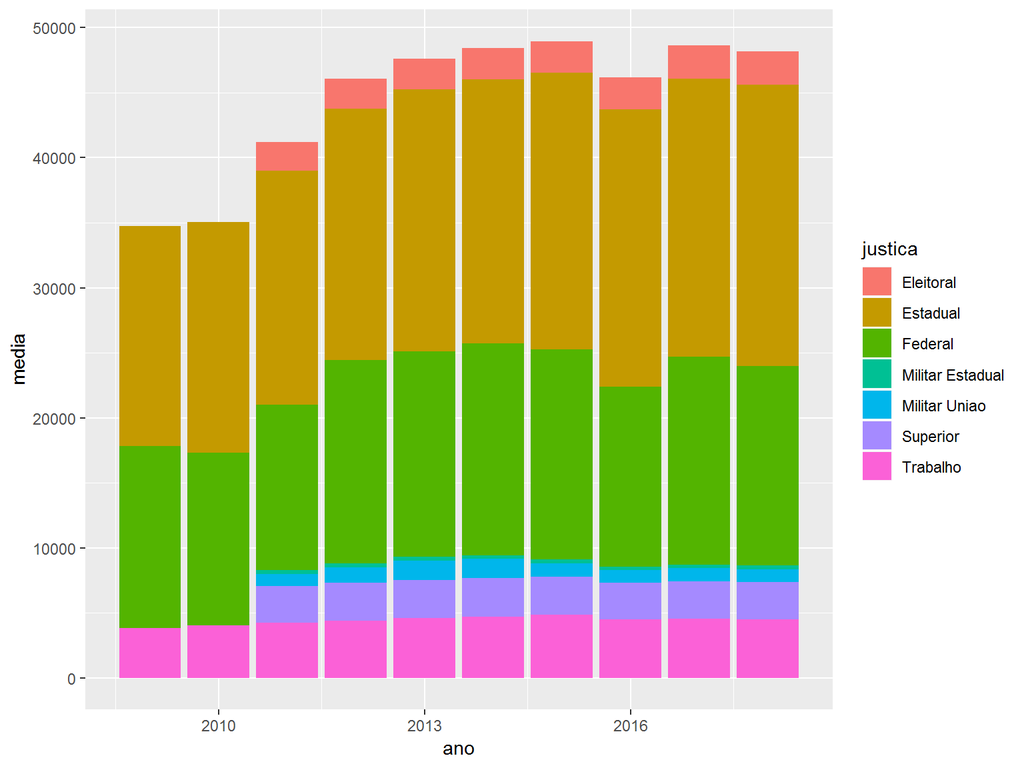

```r
jn1 <- group_by(jn, ano, justica)
jn1 <- summarise(jn1, media=mean(ftt))

ggplot(data=jn1, mapping=aes(x=ano, y=media, fill=justica))+
  geom_col()
```

# Facet

Criar vários gráficos de forma simultânea

# Statistics

A possibilidade de representar transformações estatísticas

# Coordenadas

Sistema de coordenadas

# Theme

Todos os elementos adicionais